# Shopify Data Science Challenge

On Shopify, we have exactly 100 sneaker shops, and each of these shops sells only one model of shoe. We want to do some analysis of the average order value (AOV). When we look at orders data over a 30 day window, we naively calculate an AOV of $3145.13. Given that we know these shops are selling sneakers, a relatively affordable item, something seems wrong with our analysis.

Brief answers to the questions with explanations below:

a. Think about what could be going wrong with our calculation. Think about a better way to evaluate this data. -Some orders have extremely large amounts of items or are selling the sneakers for extremely large amounts b. What metric would you report for this dataset? -Average sneaker price across stores, average number of sneakers sold throughout the month per store c. What is its value? -Average sneaker price: 152.26 -Average sneakers sold: 100

```python
import pandas as pd
import numpy as np
from matplotlib import pyplot as plt
```

```python
df = pd.read_csv('2019 Winter Data Science Intern Challenge Data Set - Sheet1.csv')
```

```python
df
```

|  | order_id | shop_id | user_id | order_amount | total_items | payment_method | created_at |
| --- | --- | --- | --- | --- | --- | --- | --- |
| 0 | 1 | 53 | 746 | 224 | 2 | cash | 2017-03-13 12:36:56 |
| 1 | 2 | 92 | 925 | 90 | 1 | cash | 2017-03-03 17:38:52 |
| 2 | 3 | 44 | 861 | 144 | 1 | cash | 2017-03-14 4:23:56 |
| 3 | 4 | 18 | 935 | 156 | 1 | credit_card | 2017-03-26 12:43:37 |
| 4 | 5 | 18 | 883 | 156 | 1 | credit_card | 2017-03-01 4:35:11 |
| ... | ... | ... | ... | ... | ... | ... | ... |
| 4995 | 4996 | 73 | 993 | 330 | 2 | debit | 2017-03-30 13:47:17 |
| 4996 | 4997 | 48 | 789 | 234 | 2 | cash | 2017-03-16 20:36:16 |
| 4997 | 4998 | 56 | 867 | 351 | 3 | cash | 2017-03-19 5:42:42 |
| 4998 | 4999 | 60 | 825 | 354 | 2 | credit_card | 2017-03-16 14:51:18 |
| 4999 | 5000 | 44 | 734 | 288 | 2 | debit | 2017-03-18 15:48:18 |

5000 rows × 7 columns

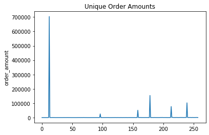

```python
#plot order_amount
plt.ylabel('order_amount')
plt.figsize = (15,10)
plt.title("Unique Order Amounts")
plt.plot(df['order_amount'].unique())
```

#### We notice in the plot above that there are some drastic jumps in order_amount which is likely causing the AOV to be so high

#### In order to better understand the order_amount it makes sense to look into the factors directly affecting it such as total_items. I also calculate the average sneaker value since that is the other value that could be causing the increased order amounts.

#### Total_items x average sneaker value = order_amount. However, it is worth noting that the relationship might not be this simple as there could be other contributing factors to the order_amount such as shipping, taxes, etc. but that is out of the scope of this analysis and for the sake of this challenge, I will ommit such confounding variables

```python
# get the average sneaker price on every order
df['avg_sneaker_value'] = df['order_amount']/df['total_items']
```

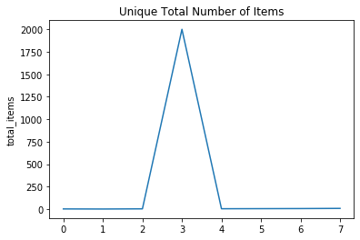

```python
#plot total_items
plt.ylabel('total_items')
plt.figsize = (15,10)
plt.title("Unique Total Number of Items")
plt.plot(df['total_items'].unique())
```

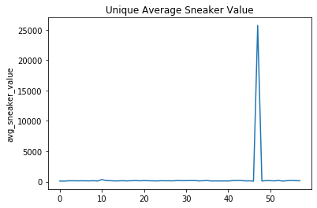

```python
#plot avg_sneaker_value
plt.ylabel('avg_sneaker_value')
plt.figsize = (15,10)
plt.title("Unique Average Sneaker Value")
plt.plot(df['avg_sneaker_value'].unique())
```

#### As expected, some of the orders have an extremely large amount of items or extremely expensive sneakers causing the order_amount to skyrocket. The reason I plot the unique values is because the goal is to simply identify whether there exist any values that are skewing the numbers

#### A good metric to report is the average sneaker price across all stores. However, much like the order_amounts, this is also skewed however, based on the unique values plot, there is only one sneaker price that can be considered an anomaly.

```python
# how many different shops were selling sneakers for extremely high amounts
df[df["avg_sneaker_value"] >= 1000]["shop_id"].unique()
```

```
array([78])
```

```python
# how are people paying shop_id 78
df[df["avg_sneaker_value"] >= 1000]["payment_method"].unique()
```

```
array(['credit_card', 'debit', 'cash'], dtype=object)
```

```python
# how many different prices did shop_id 78 sell its sneakers offer
df[df["shop_id"] == 78]["avg_sneaker_value"].unique()
```

```
array([25725.])
```

#### So it is shop_id 78 that sold all its sneakers for the price of 25,725! Surely this can't be the actual price they are selling the sneakers for especially when some people are paying in cash. Since more data is needed to figure out why these numbers are so high, I will ommit shop_id 78 from my calculation. I will not ommit other anomalous orders such as the ones with 2000 items since they do not have unreasonable sneaker prices

#### To calulcate the average across stores, I group the dataframe by shop_id, find the mean of each group and then find the mean of all the means. This method takes into account any adjustments in sneaker price a single shop might make across different orders as well the as the number of order they have made

```python
df_trimmed = df[df["shop_id"] != 78]
grouped_df = df_trimmed.groupby("shop_id")
mean_df = grouped_df.mean()
```

```python
mean_df['avg_sneaker_value'].mean()
```

```
152.26262626262627
```

## So the average sneaker price across all stores is 152.26

```python
df[df["total_items"] >= 100]
```

|  | order_id | shop_id | user_id | order_amount | total_items | payment_method | created_at | avg_sneaker_value |
| --- | --- | --- | --- | --- | --- | --- | --- | --- |
| 15 | 16 | 42 | 607 | 704000 | 2000 | credit_card | 2017-03-07 4:00:00 | 352.0 |
| 60 | 61 | 42 | 607 | 704000 | 2000 | credit_card | 2017-03-04 4:00:00 | 352.0 |
| 520 | 521 | 42 | 607 | 704000 | 2000 | credit_card | 2017-03-02 4:00:00 | 352.0 |
| 1104 | 1105 | 42 | 607 | 704000 | 2000 | credit_card | 2017-03-24 4:00:00 | 352.0 |
| 1362 | 1363 | 42 | 607 | 704000 | 2000 | credit_card | 2017-03-15 4:00:00 | 352.0 |
| 1436 | 1437 | 42 | 607 | 704000 | 2000 | credit_card | 2017-03-11 4:00:00 | 352.0 |
| 1562 | 1563 | 42 | 607 | 704000 | 2000 | credit_card | 2017-03-19 4:00:00 | 352.0 |
| 1602 | 1603 | 42 | 607 | 704000 | 2000 | credit_card | 2017-03-17 4:00:00 | 352.0 |
| 2153 | 2154 | 42 | 607 | 704000 | 2000 | credit_card | 2017-03-12 4:00:00 | 352.0 |
| 2297 | 2298 | 42 | 607 | 704000 | 2000 | credit_card | 2017-03-07 4:00:00 | 352.0 |
| 2835 | 2836 | 42 | 607 | 704000 | 2000 | credit_card | 2017-03-28 4:00:00 | 352.0 |
| 2969 | 2970 | 42 | 607 | 704000 | 2000 | credit_card | 2017-03-28 4:00:00 | 352.0 |
| 3332 | 3333 | 42 | 607 | 704000 | 2000 | credit_card | 2017-03-24 4:00:00 | 352.0 |
| 4056 | 4057 | 42 | 607 | 704000 | 2000 | credit_card | 2017-03-28 4:00:00 | 352.0 |
| 4646 | 4647 | 42 | 607 | 704000 | 2000 | credit_card | 2017-03-02 4:00:00 | 352.0 |
| 4868 | 4869 | 42 | 607 | 704000 | 2000 | credit_card | 2017-03-22 4:00:00 | 352.0 |
| 4882 | 4883 | 42 | 607 | 704000 | 2000 | credit_card | 2017-03-25 4:00:00 | 352.0 |

#### Another metric is average number of sneakers sold per store. Similar I will ommit shops with anomalous total_items

```python
# how many different shops were selling extremely high amount of sneakers per order
df[df["total_items"] >= 100]["shop_id"].unique()
```

```
array([42])
```

```python
# removing shop_id 42
df_trimmed2 = df[df["shop_id"] != 42]
grouped_df2 = df_trimmed2.groupby("shop_id")
sum_df2 = grouped_df2.sum()
```

```python
sum_df2['total_items'].mean()
```

```
99.72727272727273
```

## So the average total number of sneakers sold by each store throughout the month is 100 sneakers